# Generating Violin Plots

## Overview

This vignette will overview how to create violin plots that depict expression levels within each cluster of an input Seurat object. We will use the pbmc_small dataset that is included in Seurat (version 3) for this example.

We will begin by exporting a previously processed Seurat object into SCOTA-readable files for interactive visualization, as outlined in more detail in theExport Seurat Object Vignette.

```r
library(Seurat)
library(tidyverse)
library(patchwork)
library(cellcuratoR)

## we use the pbmc_small dataset pre-packed with Seurat

head(pbmc_small@meta.data)
```

```
##                   orig.ident nCount_RNA nFeature_RNA RNA_snn_res.0.8
## ATGCCAGAACGACT SeuratProject         70           47               0
## CATGGCCTGTGCAT SeuratProject         85           52               0
## GAACCTGATGAACC SeuratProject         87           50               1
## TGACTGGATTCTCA SeuratProject        127           56               0
## AGTCAGACTGCACA SeuratProject        173           53               0
## TCTGATACACGTGT SeuratProject         70           48               0
##                letter.idents groups RNA_snn_res.1
## ATGCCAGAACGACT             A     g2             0
## CATGGCCTGTGCAT             A     g1             0
## GAACCTGATGAACC             B     g2             0
## TGACTGGATTCTCA             A     g2             0
## AGTCAGACTGCACA             A     g2             0
## TCTGATACACGTGT             A     g1             0
```

```r
celltype <- plyr::mapvalues(x = pbmc_small@meta.data$RNA_snn_res.1,
                            from = seq(from = 0, to = 2),
                            to = c("celltype_A", "celltype_B", "celltype_C"))
pbmc_small@meta.data <- data.frame(pbmc_small@meta.data, celltype)

my_filepath <- file.path(find.package("cellcuratoR"))
print(paste0("exporting data to: ", my_filepath, "pbmc_cellcuratoR_export/"))
```

```
## [1] "exporting data to: /private/var/folders/nl/mgz6zyb95zbgxdht85f6p5j8020vg6/T/RtmptVxGA7/temp_libpath127c1f880395/cellcuratoRpbmc_cellcuratoR_export/"
```

```r
export_shiny_object(seurat_object = pbmc_small,
                    final_cluster_column_name = "RNA_snn_res.1",
                    library_id_column_name = "orig.ident",
                    classification_column_name = "celltype",
                    create_dendrogram = TRUE,
                    custom_cluster_colors = FALSE,
                    custom_library_colors = FALSE,
                    export_data_path = file.path(my_filepath, "pbmc_cellcuratoR_export/"))
                    #export_data_path = "~/Desktop/pbmc/")
```

Creating violin plots are broken into two steps. The first involves generating the data (expression values for each cluster) and the colors used for the violin plots.

```r
load(file.path(my_filepath, "pbmc_cellcuratoR_export", "seurat_obj.RData")) # Loads the seurat_obj, which renames several columns in the meta.data
                                                    # with standardized names for use in the Shiny application.

my_violin_data <- prepare_violin_data_colors(my_object = seurat_obj,
                          genes_to_investigate = c("CD79A", "CD79B", "HLA-DRA"),
                          dendrogram_input = seurat_obj@misc$dendrogram,
                          colors = seurat_obj@misc$final_colors)
# my_violin_data contains a list containing elements (1) an expression matrix from the seurat data slot and
# (2) ordered colors for the violin plot.
```

Generated data can be converted into violin plots with the contruct_violin_plot function.

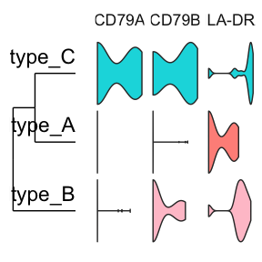

```r
theme_shiny <- function() {
      theme(
        axis.title = element_blank(),
        axis.text = element_blank(),
        axis.ticks = element_blank(),
        axis.line.y = element_blank(),
        panel.background = element_rect(fill = "white"),
        panel.grid = element_blank(),
        strip.background = element_blank(),
        strip.text.x = element_text(size = rel(1.5)),
        legend.position = "none"
      )
    }

p_violins <-
  construct_violin_plot(
    my_object = seurat_obj,
    genes_to_investigate = c("CD79A", "CD79B", "HLA-DRA"),
    dendrogram_input = seurat_obj@misc$dendrogram,
    colors = seurat_obj@misc$final_colors,
    use_noise = TRUE,
    scale = "free_x"
    ) +
  theme_shiny()
dendrogram_data <- ggdendro::dendro_data(seurat_obj@misc$dendrogram, type = "rectangle")

p_dendrogram <-
  ggdendro::segment(dendrogram_data) %>%
  ggplot2::ggplot(aes(x = x, y = y)) +
  geom_segment(
    aes(
      xend = xend,
      yend = yend
      )
    ) +
  geom_text(
    data = ggdendro::label(dendrogram_data),
    aes(label = label),
    hjust = 1,
    vjust = -0.7,
    size = 6
    ) +
  scale_y_reverse() +
  scale_x_continuous(expand = c(0, 0.6)) +
  coord_flip() +
  theme_shiny()

p_dendrogram +
  p_violins +
  patchwork::plot_layout(ncol = 2, widths = c(3, 7))
```

Colors can be manually changed easily.

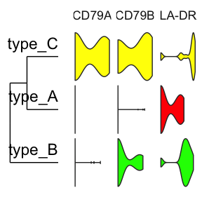

```r
p_violins <-
  construct_violin_plot(
    my_object = seurat_obj,
    genes_to_investigate = c("CD79A", "CD79B", "HLA-DRA"),
    dendrogram_input = seurat_obj@misc$dendrogram,
    colors = c("red", "green", "yellow"),
    use_noise = TRUE,
    scale = "free_x"
    ) +
  theme_shiny()
p_dendrogram +
  p_violins +
  patchwork::plot_layout(ncol = 2, widths = c(3, 7))
```

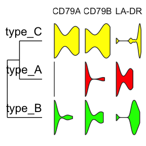

```r
p_violins <-
  construct_violin_plot(
    my_object = seurat_obj,
    genes_to_investigate = c("CD79A", "CD79B", "HLA-DRA"),
    dendrogram_input = seurat_obj@misc$dendrogram,
    colors = c("red", "green", "yellow"),
    use_noise = FALSE,
    scale = "free_x"
    ) +
  theme_shiny()
p_dendrogram +
  p_violins +
  patchwork::plot_layout(ncol = 2, widths = c(3, 7))
```

Notice how violins are drawn for all clusters in CD79B. As no cells in Celltype_A express CD79A, a violin is still not drawn for this cluster/gene combination.